# EXPLORATORY DATA ANALYSIS ON Programmers Survey

## EDUCATION LEVEL

```python
#I go with horizontal bar to represent the education level of programmers to compare education levels of respondents.
```

```python
schema.EdLevel
```

```
'Which of the following best describes the highest level of formal education that you’ve completed?'
```

```python
#Question 4: Analyze the data and show that which EdLevel's are high in Programing Coders Survey & plot its?
```

```python
survey_df.EdLevel.nunique() #This shows how many EdLevel's of Programmers
```

```
9
```

```python
survey_df.EdLevel.unique() #This shows what are the EdLevel's of Programmers are there
```

```
array(['Master’s degree (M.A., M.S., M.Eng., MBA, etc.)',
       'Bachelor’s degree (B.A., B.S., B.Eng., etc.)', nan,
       'Secondary school (e.g. American high school, German Realschule or Gymnasium, etc.)',
       'Professional degree (JD, MD, etc.)',
       'Some college/university study without earning a degree',
       'Associate degree (A.A., A.S., etc.)',
       'Other doctoral degree (Ph.D., Ed.D., etc.)',
       'Primary/elementary school',
       'I never completed any formal education'], dtype=object)
```

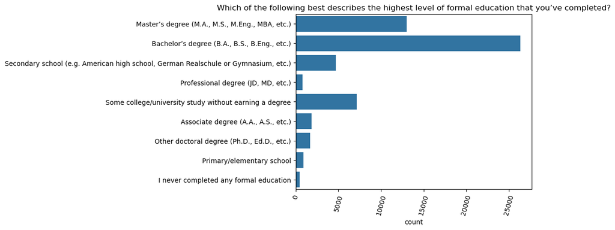

```python
sns.countplot(y= survey_df.EdLevel)
plt.xticks(rotation=75);
plt.title(schema['EdLevel'])
plt.ylabel(None)
plt.show();
```

```python
#Let's also plot undergraduate majors, but this time we'll convert the numbers into percentages, and sort by percentage values to make it easier
#to visualize the order.
```

```python
schema.UndergradMajor
```

```
'What was your primary field of study?'
```

```python
#Question 5: Which domain(or)department's are high in programming Coders survey?
```

```python
undergra_pct=survey_df.UndergradMajor.value_counts() * 100 / survey_df.UndergradMajor.count()
```

```python
undergra_pct
```

```
UndergradMajor
Computer science, computer engineering, or software engineering                   61.939193
Another engineering discipline (such as civil, electrical, mechanical, etc.)       9.354195
Information systems, information technology, or system administration              7.983168
A natural science (such as biology, chemistry, physics, etc.)                      4.316561
Mathematics or statistics                                                          3.627097
Web development or web design                                                      3.502637
A business discipline (such as accounting, finance, marketing, etc.)               2.700567
A humanities discipline (such as literature, history, philosophy, etc.)            1.969616
A social science (such as anthropology, psychology, political science, etc.)       1.821450
Fine arts or performing arts (such as graphic design, music, studio art, etc.)     1.412513
I never declared a major                                                           0.885043
A health science (such as nursing, pharmacy, radiology, etc.)                      0.487959
Name: count, dtype: float64
```

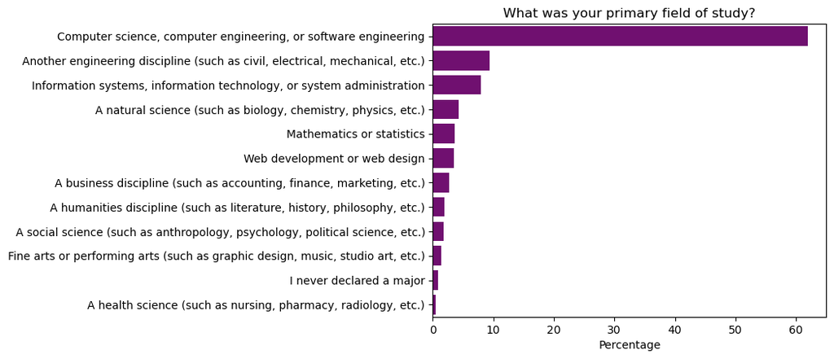

```python
undergra_pct = survey_df.UndergradMajor.value_counts() * 100 / survey_df.UndergradMajor.count()
sns.barplot(x = undergra_pct,y = undergra_pct.index, color = 'purple')
plt.title(schema.UndergradMajor)
plt.xlabel('Percentage')
plt.ylabel(None)
plt.show();
```

## EMPLOYMENT

```python
schema.Employment
```

```
'Which of the following best describes your current employment status?'
```

```python
#Question 6: what are the employment status among all the Programming Coders & show it in percentage?
```

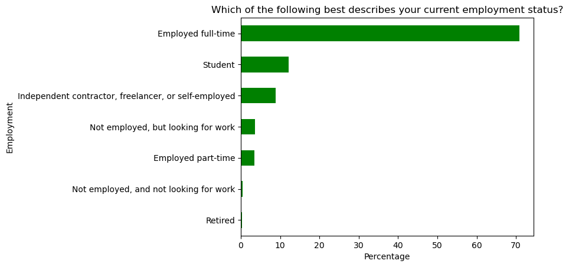

```python
(survey_df.Employment.value_counts(normalize=True, ascending =True) * 100).plot(kind = 'barh', color = 'green')
plt.title(schema.Employment)
plt.xlabel('Percentage')
plt.show();
```

```python
schema.DevType
```

```
'Which of the following describe you? Please select all that apply.'
```

```python
survey_df.DevType.unique()
```

```
array(['Developer, desktop or enterprise applications;Developer, full-stack',
       'Developer, full-stack;Developer, mobile', nan, ...,
       'Data scientist or machine learning specialist;Database administrator;Developer, back-end;Developer, front-end;System administrator',
       'Academic researcher;Data or business analyst;Data scientist or machine learning specialist;Database administrator;Designer;Developer, back-end;Developer, desktop or enterprise applications;Developer, embedded applications or devices;Developer, front-end;Developer, full-stack;Developer, game …
       'Data or business analyst;Developer, mobile;Senior executive/VP;System administrator'],
      shape=(8214,), dtype=object)
```

```python
#Question 7: What is the count of the Programmers ?
```

```python
survey_df.DevType.value_counts()
```

```
DevType
Developer, full-stack                                                                                                                                                           4396
Developer, back-end                                                                                                                                                             3056
Developer, back-end;Developer, front-end;Developer, full-stack                                                                                                                  2214
Developer, back-end;Developer, full-stack                                                                                                                                       1465
Developer, front-end                                                                                                                                                            1390
                                                                                                                                                                                ...
Database administrator;Developer, back-end;Developer, front-end;Developer, full-stack;Developer, QA or test;Senior executive/VP                                                    1
Database administrator;Developer, back-end;Developer, front-end;Developer, full-stack;Product manager;Senior executive/VP                                                          1
Developer, back-end;Developer, full-stack;Developer, mobile;DevOps specialist;Educator;System administrator                                                                        1
Data or business analyst;Database administrator;Developer, back-end;Developer, desktop or enterprise applications;Developer, front-end;Developer, mobile;Engineering manager       1
Data or business analyst;Developer, mobile;Senior executive/VP;System administrator                                                                                                1
Name: count, Length: 8213, dtype: int64
```

```python
survey_df.DevType
```

```
0        Developer, desktop or enterprise applications;...
1                  Developer, full-stack;Developer, mobile
2                                                      NaN
3                                                      NaN
4                                                      NaN
                               ...
64456                                  Senior executive/VP
64457                                                  NaN
64458                                                  NaN
64459                                                  NaN
64460                                                  NaN
Name: DevType, Length: 64306, dtype: object
```

```python
#Here there are many columns associated with different no.of values so i need to split columns.once look this code to understand upto high_respone.
```

```python
DevType = "DevType"
```

```python
def split_multicolumn(survey_df, col):
    result_df = survey_df.copy()
    options = []
    #Iterate over the column
    for idx, value in survey_df[col].dropna().items():
        #Break each value into list of options
        for option in value.split(';'):
            #Add the option as a common to result
            if not option in result_df.columns:
                result_df[option] = False
                options.append(option)
                #Mark the value in the option column as True
            result_df.at[idx, option] = True
        return result_df[options]
```

```python
dev_type_df = split_multicolumn(survey_df,DevType)
```

```python
dev_type_df
```

|  | Developer, desktop or enterprise applications | Developer, full-stack |
| --- | --- | --- |
| 0 | True | True |
| 1 | False | False |
| 2 | False | False |
| 3 | False | False |
| 4 | False | False |
| ... | ... | ... |
| 64456 | False | False |
| 64457 | False | False |
| 64458 | False | False |
| 64459 | False | False |
| 64460 | False | False |

64306 rows × 2 columns

```python
dev_type_totals = dev_type_df.sum().sort_values(ascending=False)
```

```python
dev_type_totals
```

```
Developer, desktop or enterprise applications    1
Developer, full-stack                            1
dtype: int64
```

```python
survey_df.LanguageWorkedWith
```

```
0                                   C#;HTML/CSS;JavaScript
1                                         JavaScript;Swift
2                                 Objective-C;Python;Swift
3                                                      NaN
4                                        HTML/CSS;Ruby;SQL
                               ...
64456                                                  NaN
64457    Assembly;Bash/Shell/PowerShell;C;C#;C++;Dart;G...
64458                                                  NaN
64459                                             HTML/CSS
64460                      C#;HTML/CSS;Java;JavaScript;SQL
Name: LanguageWorkedWith, Length: 64306, dtype: object
```

```python
survey_df.groupby('Country')[['WorkWeekHrs', 'Age']].mean()
```

| Country | WorkWeekHrs | Age |
| --- | --- | --- |
| Afghanistan | 46.500000 | 23.571429 |
| Albania | 43.962963 | 26.766667 |
| Algeria | 36.862069 | 28.019608 |
| Andorra | 42.000000 | 39.000000 |
| Angola | 24.500000 | 25.500000 |
| ... | ... | ... |
| Venezuela, Bolivarian Republic of... | 40.125000 | 29.090909 |
| Viet Nam | 41.391667 | 25.786585 |
| Yemen | 40.000000 | 31.000000 |
| Zambia | 38.000000 | 29.000000 |
| Zimbabwe | 39.928571 | 25.578947 |

183 rows × 2 columns

```python
countries_df = survey_df.groupby('Country')[['WorkWeekHrs']].mean().sort_values('WorkWeekHrs', ascending = False)
```

```python
countries_df
```

| Country | WorkWeekHrs |
| --- | --- |
| Kuwait | 58.222222 |
| Iraq | 52.153846 |
| Grenada | 50.000000 |
| Maldives | 47.300000 |
| Afghanistan | 46.500000 |
| ... | ... |
| North Korea | NaN |
| Saint Lucia | NaN |
| Sierra Leone | NaN |
| Solomon Islands | NaN |
| Timor-Leste | NaN |

183 rows × 1 columns

```python
high_response_countries_df = countries_df.loc[survey_df.Country.value_counts() > 250].head(10)
```

```python
high_response_countries_df
```

| Country | WorkWeekHrs |
| --- | --- |
| Iran | 44.337748 |
| Israel | 43.915094 |
| China | 42.150000 |
| United States | 41.802982 |
| Greece | 41.402724 |
| Viet Nam | 41.391667 |
| South Africa | 41.023460 |
| Turkey | 40.982143 |
| Sri Lanka | 40.612245 |
| New Zealand | 40.457551 |

```python
schema.YearsCodePro
```

```
'NOT including education, how many years have you coded professionally (as a part of your work)?'
```

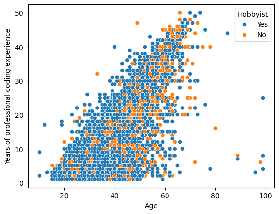

```python
sns.scatterplot(x= 'Age', y = 'YearsCodePro', hue = 'Hobbyist', data = survey_df)
plt.xlabel("Age")
plt.ylabel("Years of professional coding experience")
plt.show();
```

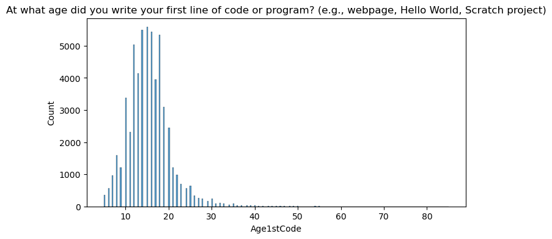

```python
plt.figure(figsize =(8,4)) #for assigning the size of the grid
plt.title(schema.Age1stCode)
sns.histplot(survey_df.Age1stCode)
plt.show();
```

## INFERENCES AND CONCLUSIONS

We've drawn many interesting inferences from the survey, here's a summary of the few of them:

Based on the demographics of the survey respondents, we can infer that the survey is somewhat representative of the overall programming community, although it definitely has fewer responses from programmers in non-English-speaking countries and from women & non-binary genders.

The programming community is not as diverse as it can be, and although things are improving, we should take more efforts to support & encourage members of underrepresented communities -whether it is in terms of age, country, race, gender or otherwise.

Most programmers hold a college degree, although a fairly large percentage did not have computer science as their major in college, so a computer science degree isn't compulsory for learning to code or building a career in programming.

A significant percentage of programmers either work part time or as freelancers, and this can be a great way to break into the field, especially when you're just getting started.

Programmers around the world seems be working for around 40 hours a week on average, with slight variations by country.

Finally: You can learn and start programming professionally at any age, and you're likely to have a long and fulfilling career if you also enjoy programming as a hobby.

## REFERENCES AND FUTURE WORK

There's a wealth of information to be discovered using the survey, and we've barely scratched the surface. Here are some ideas for further exploration:

Analyze salary trends by country and experience

Compare results with previous survey years

Prepare an analysis focusing on diversity - and identify areas where underrepresented communities are with the majority (e.g. education) and where they aren't (e.g. salaries)

Compare the results of this year's survey with the previous years and identify interesting trends

Reference :

DataSet : https://www.kaggle.com/datasets/aitzaz/stack-overflow-developer-survey-2020(Which i used)

If you need to check out with other datasets check at STEP-6.

### TOOLS & SKILLS USED :

```
                 Data Cleaning and Preprocessing
                 Exploratory Data Analysis (EDA)
                 Data Visualization
                 Pandas & Numpy Operations
                 Insight generation
```